# 003 ICU

Katie Gostic

11/1/2017

Notes on data formatting from Deborah Wentworth:

- symdur is symptom duration (days) prior to enrollment
- date info is for enrollment date
- fluvac6 and fluvac12 are flu vaccination in last 6 or last 12 months
- anyvac combines values from fluvac6 and fluvac12, whichever was collected for a given patient is reported.
- anyav is use of antivirals at any time
- anydx is any diagnosis in the medical history section
- flutype is subtype: 1=H1N1, 2=H3N2, 3=flu B, 4=PCR negative, 5=Inf A, subtype unknown, and 6=coinfection with multiple strains
- resolved is symptom resolution within 14 days
- country code is the 3 letter code for country of enrollment - think the abbreviations will be obvious

#### Visualize the relationship between age and prob of H1N1 infection

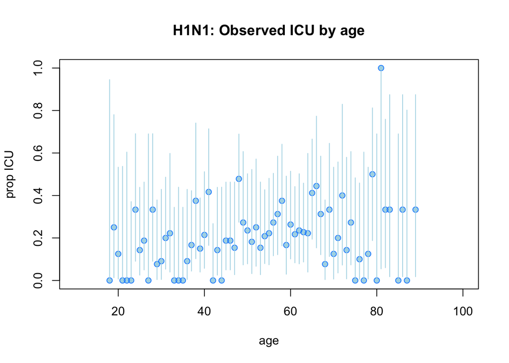

#### Visualize the relationship between age and prob of H3N2 infection

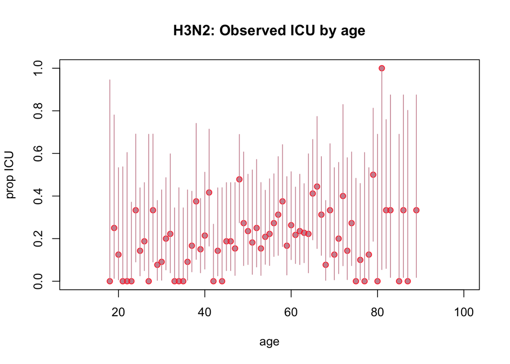

#### Visualize the relationship between country and prolonged symptoms

H1N1

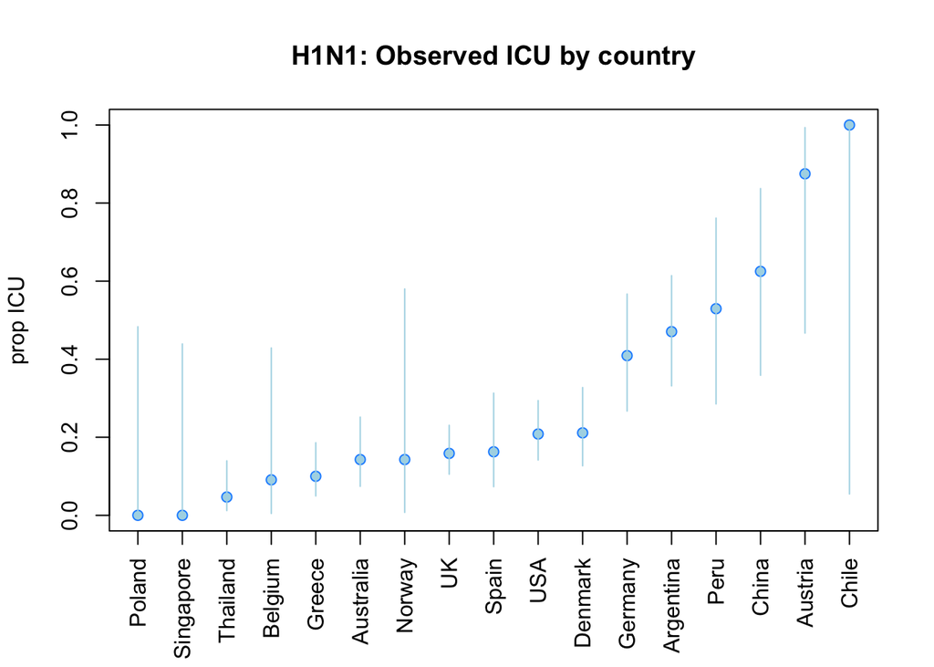

H3N2

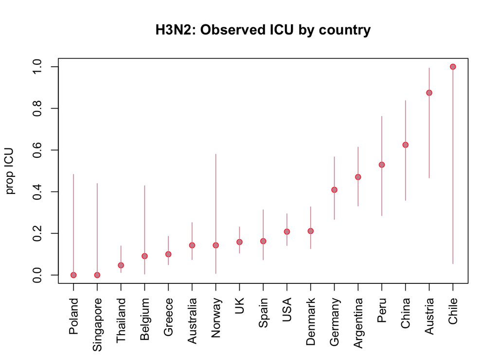

#### Visualize the relationship between season and prob infection

H1N1

[figure not shown]

H3N2

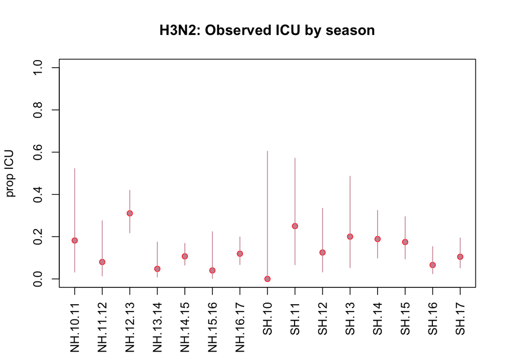

## Set up a logistic regression that includes the following predictors:

- age
- imprinting status
- vaccination status
- antiviral use
- season
- country

### Clean data for fitting

```
##
## Argentina Australia   Austria   Belgium     Chile     China   Denmark
##        51        70         8        11         1        16        71
##   Germany    Greece    Norway      Peru    Poland Singapore     Spain
##        44        90         7        17         6         7        43
##  Thailand        UK       USA
##        64       145       120
```

```
## [1] 771
```

```
##
## Argentina Australia   Belgium     China   Denmark   Germany    Greece
##       117       123         5         7        32        21        24
##      Peru Singapore     Spain  Thailand        UK       USA
##         9        24        31       125        93       180
```

```
## [1] 791
```

### First fit a model where the only independent variable is age

Treat vaccination, antivial use, underlying symptoms, country and season as blocking variables with fixed effects

```r
library(splines)
## H1N1 fit to country, season and medical history only (no effect of age or imprinting)
fit0 = glm(anyicu ~ anyav + anydx + country + H3.valid*season + H3.valid*anyvac, data = train, family = binomial)
summary(fit0)
```

```
##
## Call:
## glm(formula = anyicu ~ anyav + anydx + country + H3.valid * season +
##     H3.valid * anyvac, family = binomial, data = train)
##
## Deviance Residuals:
##     Min       1Q   Median       3Q      Max
## -1.3778  -0.6209  -0.4818  -0.1541   2.7951
##
## Coefficients: (2 not defined because of singularities)
##                            Estimate Std. Error z value Pr(>|z|)
## (Intercept)                -1.35187    1.05605  -1.280  0.20050
## anyav1                      0.10232    0.38074   0.269  0.78812
## anydx1                      0.50362    0.43514   1.157  0.24713
## countryAustralia           -1.84209    0.80310  -2.294  0.02181 *
## countryDenmark             -0.89469    0.94633  -0.945  0.34444
## countryGermany             -0.18636    1.04901  -0.178  0.85899
## countryGreece              -1.69061    1.02311  -1.652  0.09845 .
## countryOther               -0.64674    0.86248  -0.750  0.45334
## countryPeru                18.28962 2278.26879   0.008  0.99359
## countrySpain               -1.45993    1.04268  -1.400  0.16146
## countryThailand            -2.63647    0.97973  -2.691  0.00712 **
## countryUK                  -1.39511    0.94278  -1.480  0.13893
## countryUSA                 -0.90143    0.91546  -0.985  0.32478
## H3.valid1                  14.91918 2637.95592   0.006  0.99549
## seasonNH.10.11              1.39191    0.51877   2.683  0.00729 **
## seasonNH.11.12            -15.75951 3956.18038  -0.004  0.99682
## seasonNH.12.13              0.95668    0.85185   1.123  0.26141
## seasonNH.13.14              0.11203    0.63892   0.175  0.86081
## seasonNH.14.15              3.01353    1.57623   1.912  0.05589 .
## seasonNH.15.16              0.40414    0.57064   0.708  0.47881
## seasonNH.16.17            -15.11023 2105.45818  -0.007  0.99427
## seasonSH.10                 1.88671    1.38588   1.361  0.17339
## seasonSH.11                 1.19830    1.10619   1.083  0.27869
## seasonSH.12               -34.50382 4565.28980  -0.008  0.99397
## seasonSH.13                 0.86317    1.13457   0.761  0.44678
## seasonSH.14               -14.92117 3956.18043  -0.004  0.99699
## seasonSH.15                 0.12730    1.41829   0.090  0.92848
## seasonSH.16                -0.54188    1.11497  -0.486  0.62696
## seasonSH.17               -15.49100 2637.95579  -0.006  0.99531
```

[output cut: 13 more lines]

```
## H3.valid1:seasonSH.15     -13.46018 2637.95643  -0.005  0.99593
## H3.valid1:seasonSH.16     -14.63801 2637.95642  -0.006  0.99557
## H3.valid1:seasonSH.17            NA         NA      NA       NA
## H3.valid1:anyvac1           0.04226    0.69123   0.061  0.95125
## ---
## Signif. codes:  0 '***' 0.001 '**' 0.01 '*' 0.05 '.' 0.1 ' ' 1
##
## (Dispersion parameter for binomial family taken to be 1)
##
##     Null deviance: 434.36  on 467  degrees of freedom
## Residual deviance: 365.52  on 424  degrees of freedom
##   (24 observations deleted due to missingness)
## AIC: 453.52
##
## Number of Fisher Scoring iterations: 16
```

```r
## H1N1 fit to age only, plus fixed effects of vaccination, av use, underlying conditions, country and season
fit1 = glm(anyicu ~ age + anyav + anydx + country + H3.valid*season + H3.valid*anyvac, data = train, family = binomial)
summary(fit1)
```

```
##
## Call:
## glm(formula = anyicu ~ age + anyav + anydx + country + H3.valid *
##     season + H3.valid * anyvac, family = binomial, data = train)
##
## Deviance Residuals:
##     Min       1Q   Median       3Q      Max
## -1.5450  -0.6110  -0.4511  -0.1305   2.6569
##
## Coefficients: (2 not defined because of singularities)
##                            Estimate Std. Error z value Pr(>|z|)
## (Intercept)                -3.28331    1.37577  -2.387  0.01701 *
## age                         0.04088    0.01828   2.237  0.02530 *
## anyav1                      0.08505    0.38463   0.221  0.82500
## anydx1                      0.33988    0.44219   0.769  0.44211
## countryAustralia           -1.87832    0.81551  -2.303  0.02126 *
## countryDenmark             -0.78996    0.94728  -0.834  0.40432
## countryGermany             -0.02745    1.05730  -0.026  0.97929
## countryGreece              -1.80273    1.02520  -1.758  0.07868 .
## countryOther               -0.66836    0.86002  -0.777  0.43707
## countryPeru                18.21062 2270.15176   0.008  0.99360
## countrySpain               -1.53285    1.04518  -1.467  0.14249
## countryThailand            -2.63198    0.98280  -2.678  0.00741 **
## countryUK                  -1.39951    0.94282  -1.484  0.13770
## countryUSA                 -0.95107    0.91597  -1.038  0.29913
## H3.valid1                  14.91284 2691.76452   0.006  0.99558
## seasonNH.10.11              1.30916    0.52292   2.504  0.01230 *
## seasonNH.11.12            -15.77827 3956.18038  -0.004  0.99682
## seasonNH.12.13              0.96589    0.86519   1.116  0.26426
## seasonNH.13.14              0.10136    0.64118   0.158  0.87439
## seasonNH.14.15              3.18380    1.59385   1.998  0.04577 *
## seasonNH.15.16              0.25940    0.57435   0.452  0.65154
## seasonNH.16.17            -15.40599 2134.38793  -0.007  0.99424
## seasonSH.10                 1.73957    1.39499   1.247  0.21239
## seasonSH.11                 1.29180    1.11514   1.158  0.24670
## seasonSH.12               -34.98737 4561.24450  -0.008  0.99388
## seasonSH.13                 0.83643    1.13074   0.740  0.45947
## seasonSH.14               -15.22225 3956.18044  -0.004  0.99693
## seasonSH.15                -0.03824    1.41470  -0.027  0.97844
## seasonSH.16                -0.81379    1.13044  -0.720  0.47159
```

[output cut: 14 more lines]

```
## H3.valid1:seasonSH.15     -13.57303 2691.76500  -0.005  0.99598
## H3.valid1:seasonSH.16     -14.50528 2691.76501  -0.005  0.99570
## H3.valid1:seasonSH.17            NA         NA      NA       NA
## H3.valid1:anyvac1           0.09001    0.69403   0.130  0.89681
## ---
## Signif. codes:  0 '***' 0.001 '**' 0.01 '*' 0.05 '.' 0.1 ' ' 1
##
## (Dispersion parameter for binomial family taken to be 1)
##
##     Null deviance: 434.36  on 467  degrees of freedom
## Residual deviance: 360.29  on 423  degrees of freedom
##   (24 observations deleted due to missingness)
## AIC: 450.29
##
## Number of Fisher Scoring iterations: 16
```

```r
## H1N1 fit to age plus imprinting, plus fixed effects of vaccination, av use, underlying conditions, country and season
fit2 = glm(anyicu ~ age + imp.status + anyav + anydx + country + H3.valid*season + H3.valid*anyvac, data = train, family = binomial)
summary(fit2)
```

```
##
## Call:
## glm(formula = anyicu ~ age + imp.status + anyav + anydx + country +
##     H3.valid * season + H3.valid * anyvac, family = binomial,
##     data = train)
##
## Deviance Residuals:
##     Min       1Q   Median       3Q      Max
## -1.5292  -0.6131  -0.4481  -0.1435   2.6861
##
## Coefficients: (2 not defined because of singularities)
##                            Estimate Std. Error z value Pr(>|z|)
## (Intercept)                -3.78236    1.48593  -2.545  0.01091 *
## age                         0.04843    0.02038   2.376  0.01750 *
## imp.statuslow               0.34243    0.36390   0.941  0.34671
## anyav1                      0.07036    0.38548   0.183  0.85516
## anydx1                      0.35018    0.44116   0.794  0.42733
## countryAustralia           -1.83540    0.81604  -2.249  0.02450 *
## countryDenmark             -0.78752    0.95005  -0.829  0.40715
## countryGermany             -0.03172    1.05497  -0.030  0.97601
## countryGreece              -1.76120    1.02585  -1.717  0.08601 .
## countryOther               -0.64831    0.85990  -0.754  0.45089
## countryPeru                18.20954 2278.80080   0.008  0.99362
## countrySpain               -1.53513    1.04481  -1.469  0.14175
## countryThailand            -2.62872    0.98231  -2.676  0.00745 **
## countryUK                  -1.37931    0.94323  -1.462  0.14365
## countryUSA                 -0.91841    0.91804  -1.000  0.31711
## H3.valid1                  14.62901 2697.69438   0.005  0.99567
## seasonNH.10.11              1.30683    0.52224   2.502  0.01234 *
## seasonNH.11.12            -15.74423 3956.18038  -0.004  0.99682
## seasonNH.12.13              0.93643    0.85973   1.089  0.27606
## seasonNH.13.14              0.07345    0.64176   0.114  0.90888
## seasonNH.14.15              2.99478    1.60605   1.865  0.06222 .
## seasonNH.15.16              0.22374    0.57539   0.389  0.69738
## seasonNH.16.17            -15.35771 2133.19242  -0.007  0.99426
## seasonSH.10                 1.78110    1.39682   1.275  0.20227
## seasonSH.11                 1.22389    1.11614   1.097  0.27284
## seasonSH.12               -34.94767 4565.55533  -0.008  0.99389
## seasonSH.13                 0.79647    1.13247   0.703  0.48187
## seasonSH.14               -15.23663 3956.18044  -0.004  0.99693
```

[output cut: 16 more lines]

```
## H3.valid1:seasonSH.15     -13.54311 2697.69484  -0.005  0.99599
## H3.valid1:seasonSH.16     -14.47054 2697.69484  -0.005  0.99572
## H3.valid1:seasonSH.17            NA         NA      NA       NA
## H3.valid1:anyvac1           0.02982    0.70383   0.042  0.96620
## ---
## Signif. codes:  0 '***' 0.001 '**' 0.01 '*' 0.05 '.' 0.1 ' ' 1
##
## (Dispersion parameter for binomial family taken to be 1)
##
##     Null deviance: 434.36  on 467  degrees of freedom
## Residual deviance: 359.37  on 422  degrees of freedom
##   (24 observations deleted due to missingness)
## AIC: 451.37
##
## Number of Fisher Scoring iterations: 16
```

```r
par(mfrow = c(1, 2), las = 3, mar = c(6, 6, 6, 3), cex.axis = .7)
library(gam)
```

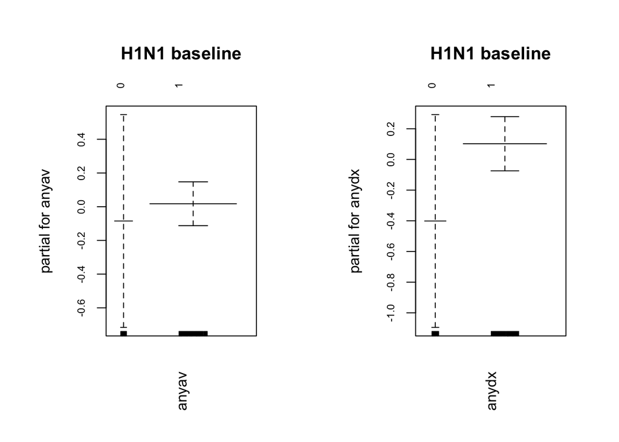

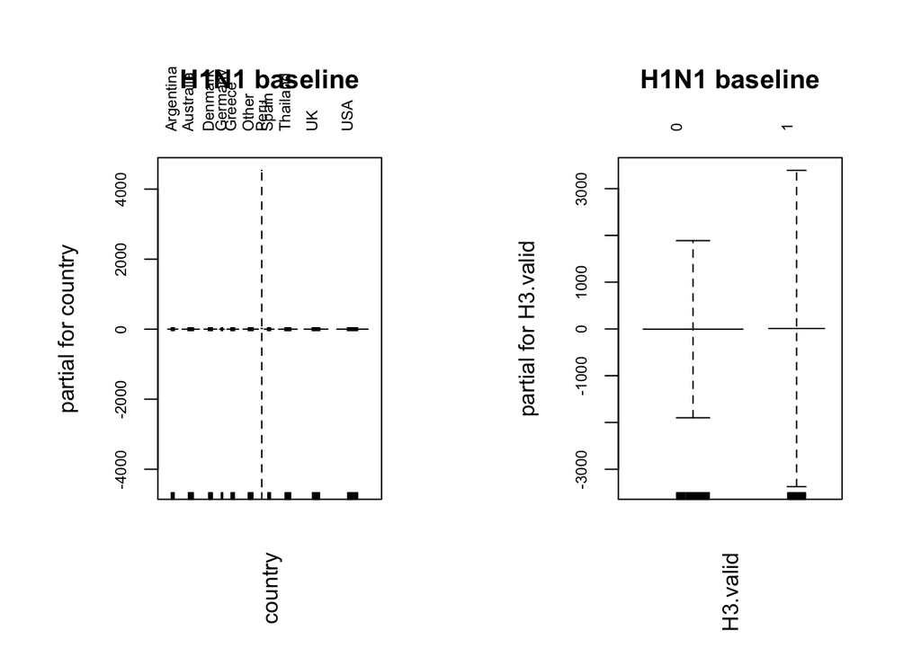

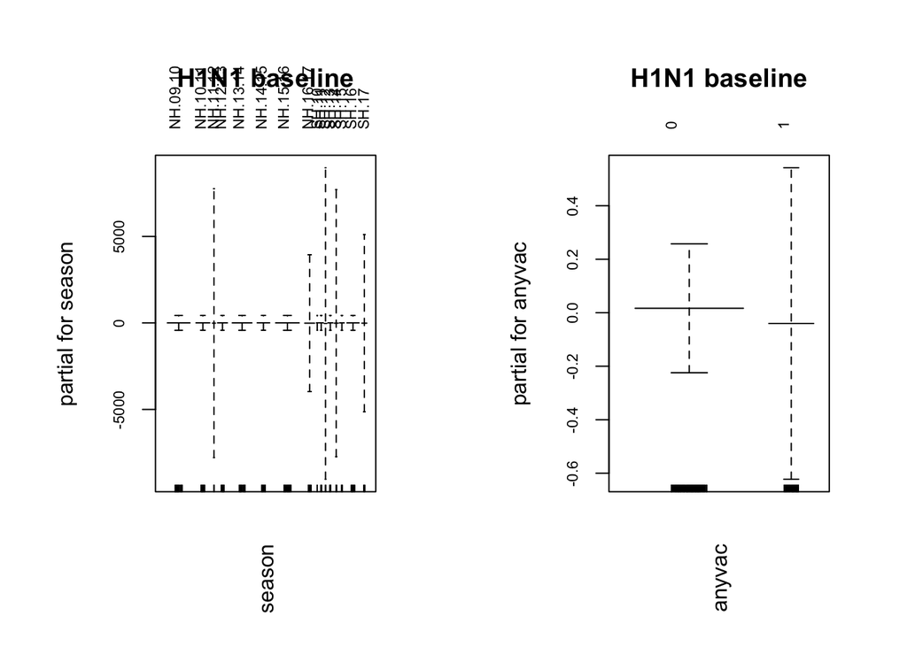

```r
plot.gam(fit0, se = T, col = 'darkslateblue', main = 'H1N1 baseline')
```

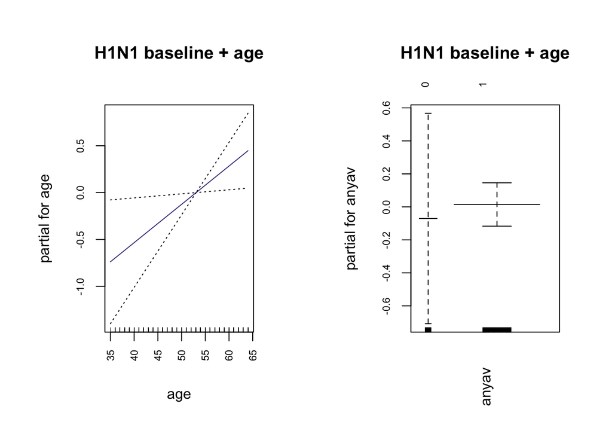

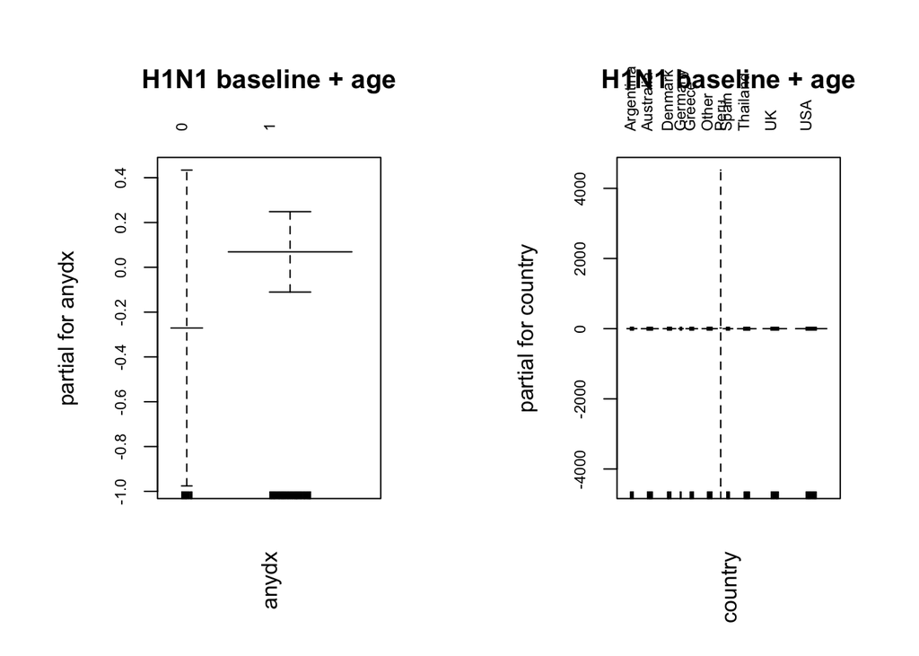

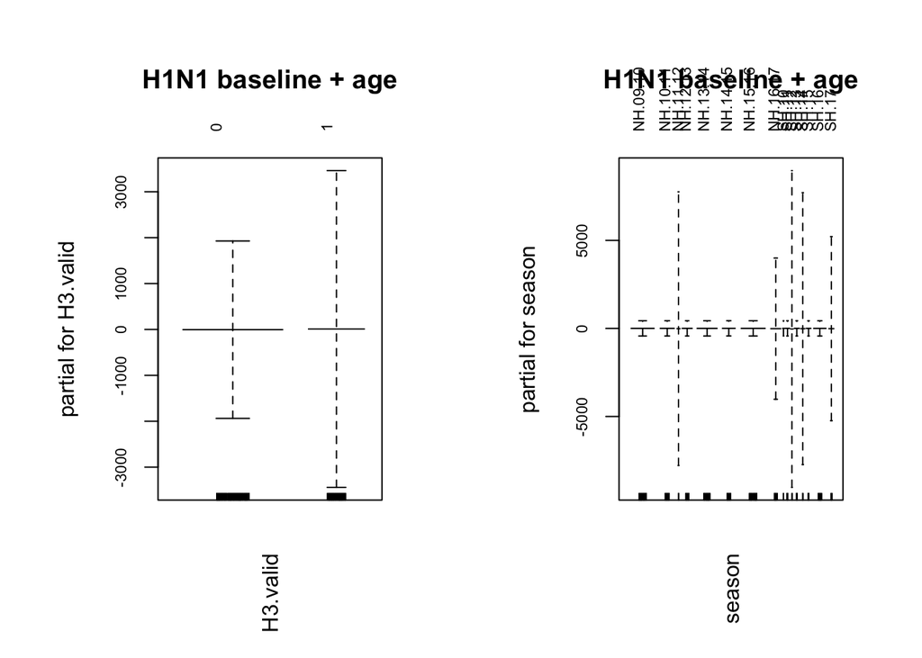

```r
plot.gam(fit1, se = T, col = 'darkslateblue', main = 'H1N1 baseline + age')
```

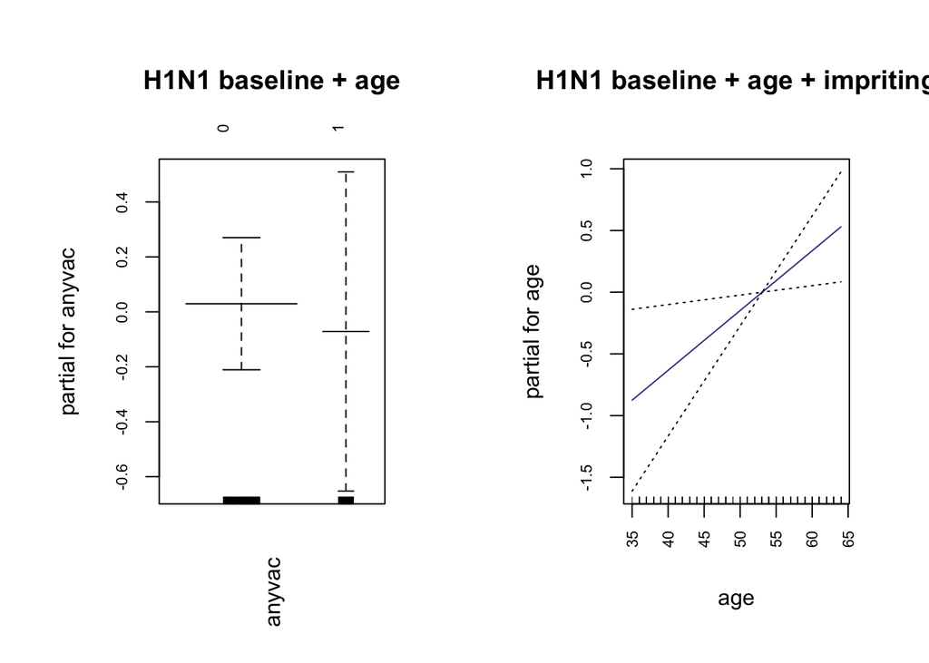

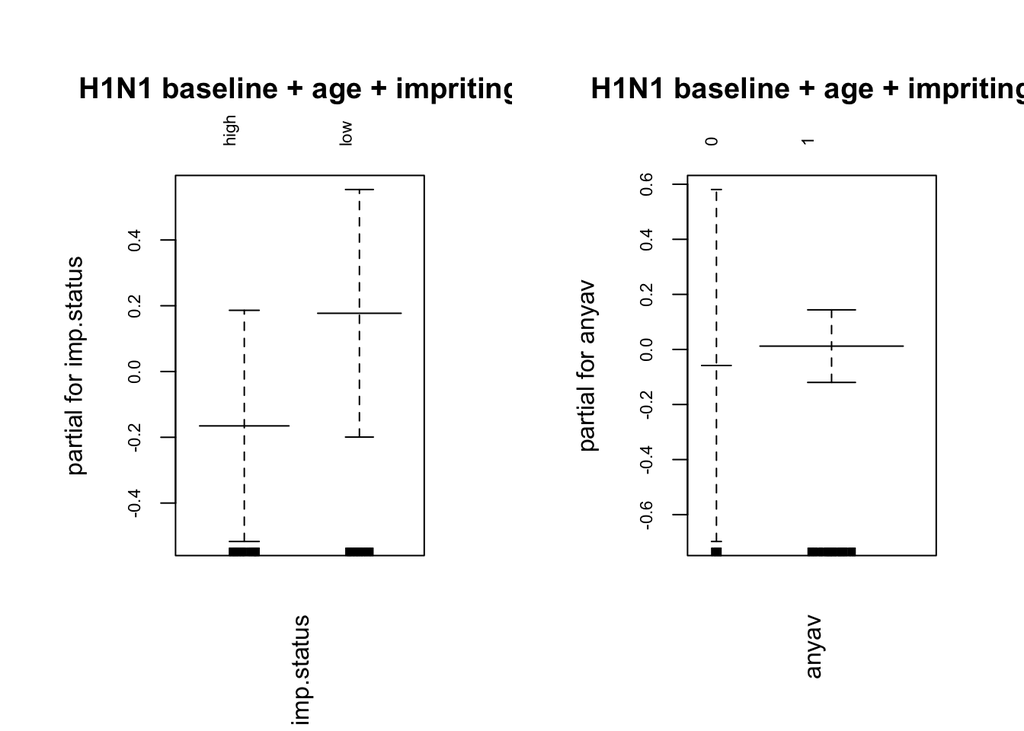

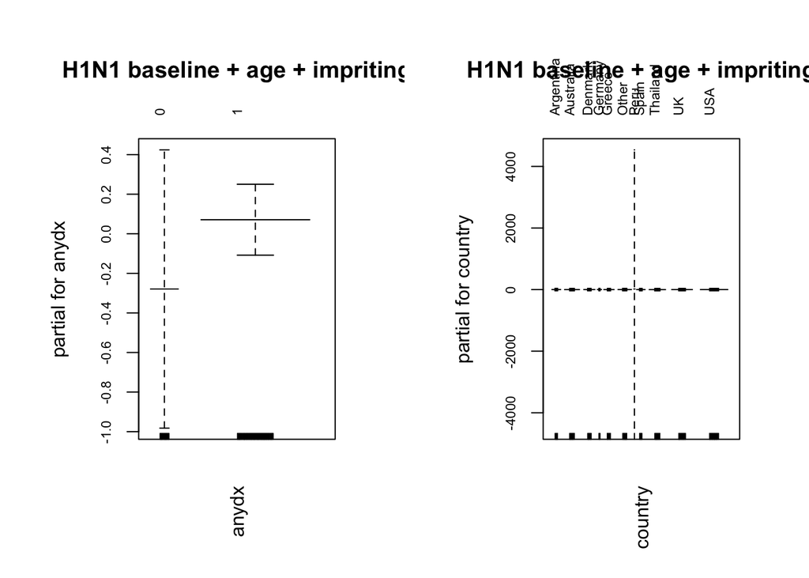

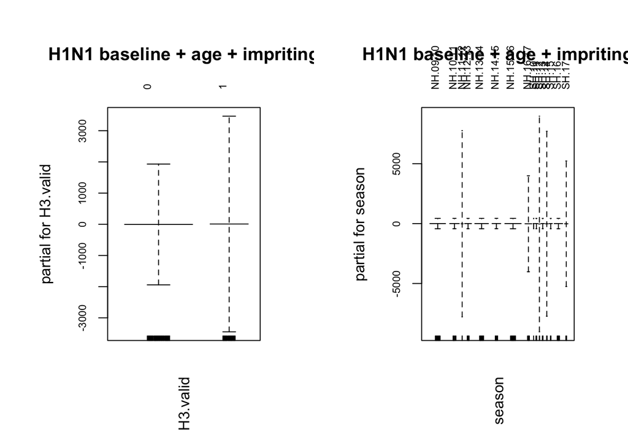

```r
plot.gam(fit2, se = T, col = 'darkslateblue', main = 'H1N1 baseline + age + impriting')
```

```r
# plot.gam(fit3, se = T, col = 'darkslateblue', main = 'H1N1 baseline + age + sub')
# plot.gam(fit4, se = T, col = 'darkslateblue', main = 'H1N1 baseline + age + N')
pdf('003ICU_constrained.pdf')
plot.gam(fit2, se = T, col = 'darkslateblue', main = 'H1N1 baseline + age + impriting')
dev.off()
```

```r
# Predict probs for each patient
probs0 = predict(fit0, newdata = test, type = 'response')
probs1 = predict(fit1, newdata = test, type = 'response')
probs2 = predict(fit2, newdata = test, type = 'response')
```

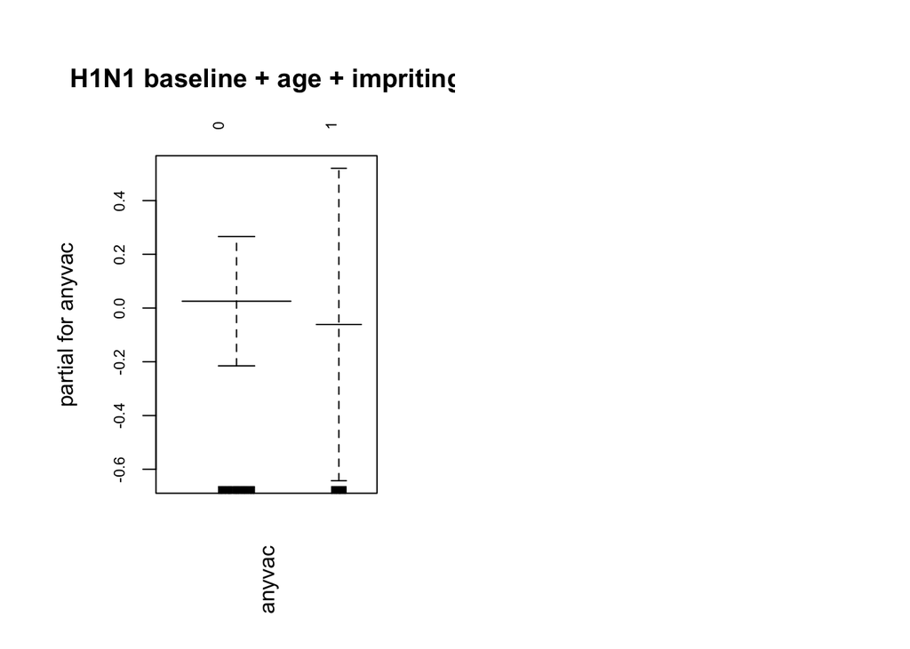

```r
# probs3 = predict(fit3, newdata = test, type = 'response')
# probs4 = predict(fit4, newdata = test, type = 'response')

# Create a predict object
pr0 = prediction(probs0, test$anyicu)
pr1 = prediction(probs1, test$anyicu)
pr2 = prediction(probs2, test$anyicu)
# pr3 = prediction(probs3, test$anyicu)
# pr4 = prediction(probs4, test$anyicu)

# Assess tp and fp
prf0 = performance(pr0, measure = 'tpr', x.measure = 'fpr')
prf1 = performance(pr1, measure = 'tpr', x.measure = 'fpr')
prf2 = performance(pr2, measure = 'tpr', x.measure = 'fpr')
# prf3 = performance(pr3, measure = 'tpr', x.measure = 'fpr')
# prf4 = performance(pr4, measure = 'tpr', x.measure = 'fpr')

# Calculate AUCs
auc = sapply(list(pr0, pr1, pr2), FUN = function(xx){aa = performance(xx, measure = 'auc')
                                                                      round(aa@y.values[[1]], 3) })

# Plot AUC
par(mfrow = c(1,1))
```

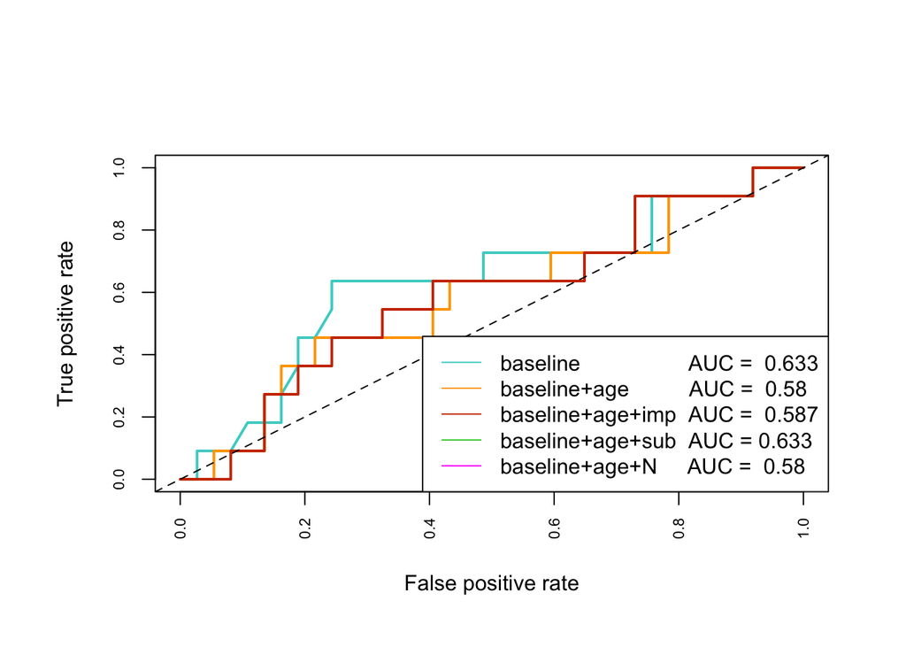

```r
plot(prf0, lwd = 2, col = cols[3])
plot(prf1, col = cols[2], add = TRUE, lwd = 2)
plot(prf2, col = cols[1], add = TRUE, lwd = 2)
# plot(prf3, col = 'limegreen', add = TRUE, lwd = 2)
# plot(prf4, col = 'magenta', add = TRUE, lwd = 2)
abline(a = 0, b = 1, lty = 2)
legend('bottomright', paste(c('baseline                  AUC = ', 'baseline+age          AUC = ', 'baseline+age+imp  AUC = ', 'baseline+age+sub  AUC =', 'baseline+age+N     AUC = '), auc), col = c(cols[3:1], 'limegreen', 'magenta'),  lty = 1)
```

```r
pdf('003ICU_AUC_constrained.pdf')
par(lwd = 3.5, cex = 1.5, cex.axis = 1.5, cex.lab = 1.5)
# Plot AUC
par(mfrow = c(1,1))
plot(prf0, col = cols[3])
plot(prf1, col = cols[2], add = TRUE)
plot(prf2, col = cols[1], add = TRUE)
# plot(prf3, col = 'limegreen', add = TRUE, lwd = 2)
# plot(prf4, col = 'magenta', add = TRUE, lwd = 2)
abline(a = 0, b = 1, lty = 2)
legend('bottomright', paste(c('baseline                  AUC = ', 'baseline+age          AUC = ', 'baseline+age+imp  AUC = ', 'baseline+age+sub  AUC =', 'baseline+age+N     AUC = '), auc), col = c(cols[3:1], 'limegreen', 'magenta'),  lty = 1)
dev.off()
```

```r
# Calculate AUC for test data
AIC = c(fit0$aic, fit1$aic, fit2$aic); names(AIC) =  c('baseline', 'baseline+age', 'baseline+age+imp')
del.AIC = sort(AIC - min(AIC))
del.AIC
```

```
##     baseline+age baseline+age+imp         baseline
##         0.000000         1.082953         3.225359
```

```r
#
# load('master.AIC.table.constrained.RData')
# master.AIC.table['003ICU', c('baseline', 'baseline+age', 'baseline+age+imp', 'baseline+age+sub', 'baseline+age+N')] = AIC - min(AIC)
# save(master.AIC.table, file = 'master.AIC.table.constrained.RData')
# rm(master.AIC.table)
```